# Comments for Lab 10 - Exploring Questions from the 2024 National Elections Pilot Study

Author

Published

April 17, 2025

# Overview

In this lab, we’ll continue exploring data from the National Election Studies 2024 Pilot Study.

From last week’s lab you should have identified some variables of interest in the data, recoded them as needed, and begun to formulate some research questions.

In this week’s lab, we’ll pick up where we left off:

1. Set up your work space (5 minutes)
2. Load the data from last week (5 minutes)
3. Quickly summarize the data (15)
4. Revisit and revise your research question and expectations (15 minutes)
5. Estimate models to explore your question (10 minutes)
6. Interpret the results of your model (30 minutes)

One of these 6 tasks will be randomly selected as the graded question for the lab.

```r
set.seed(11042024)
graded_question <- sample(1:6,size = 1)
paste("Question",graded_question,"is the graded question for this week")
```

```
[1] "Question 6 is the graded question for this week"
```

|  | Group | 1 | 2 | 3 | 4 |
| --- | --- | --- | --- | --- | --- |
| 1 | Group 1 | Gurpartap Singh | Niyah Whitten | Marisa Coghlin | Aidan Choi |
| 2 | Group 2 | Sylvie Watts | Amani Diallo | Sinclair Harris | Peter Zucker |
| 3 | Group 3 | Joshua Okwaning | Eiffel Sunga | Jenna Hercher | Ella Hendelman |
| 4 | Group 4 | Jacqueline Zhang | Charlie Jeffers | Meleah Neely | Nene Mokonchu |
| 5 | Group 5 | Talib Reddick | Zoe Kaufman | Jenna Lowry | Harry Laferriere |
| 6 | Group 6 | Tess Naquet-Radiguet | Anisha Kumar | Nash Riebe | Sophia Wotman |
| 7 | Group 7 | Ben Buka | Ianthe Ince | Riya Srinivasan | Kaelah Kimura |

# Goals

This week’s lab will give you practice:

- Loading libraries needed to do your analysis (Q1)
- Loading data you’ve already recoded (Q2)
- Summarizing data (Q3)
- Translating research questions into empirical expectations
- Estimating linear models (Q5)
- Interpreting the substantive and statistical significance of these models (Q6)

# Workflow

## Please render this .qmd file

As with every lab, you should:

- Download the file
- Save it in your course folder
- **Update the `author:` section of the YAML header to include the names of your group members in attendance.**
- Render the document
- Open the html file in your browser (Easier to read)
- Write your code in the **chunks provided under each section**
- Comment out or delete any test code you do not need
- **Render the document again after completing a section or chunk** (Error checking)
- Upload the final lab to [Canvas](https://canvas.brown.edu/courses/1094972/assignments).

# 1 Set up your workspace

Please load the libraries you will use in your analysis.

## 1.1 Load Packages

```r
# Libraries
library(tidyverse)
library(haven)
library(labelled)
library(kableExtra)
library(texreg)
library(ggpubr)
library(patchwork)
library(DeclareDesign)
```

## 1.2 Set your working directory in R Studio

In R studio **set your working directory** to the **folder where this lab is** saved by clicking > Session > Set Working Directory > To Source File Location

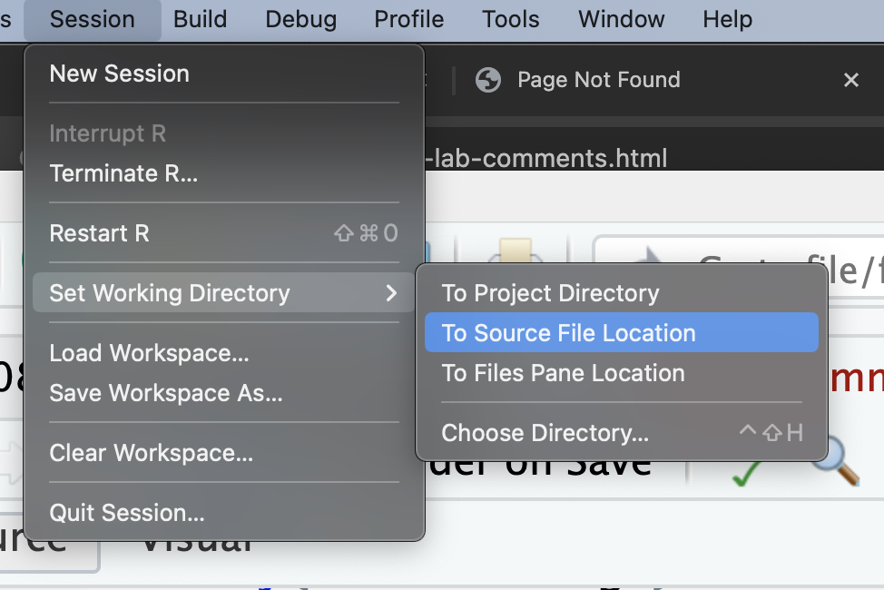

After doing so uncomment `getwd()` Should print out something like

> “~/Desktop/pols1600/labs/”

Depending on where your lab is saved

```r
# In the Top Panel of RStudio Click
# Session > Set Working Directory > Source File Location

# Uncomment to Check Where Your File is Saved
# getwd()
```

**Note**

If `getwd()` says something like ‘~/Downloads/’ click: “File > Save As” and **save this lab** in your **course folder**. Then **close** the version `09-lab.qmd` that was opened from your Downloads folder and **open** the version of `09-lab.qmd` that now exists in your course folder.

# 2 Load the data from last week.

Please uncomment and if needed, update, the code below to load the data from last week

```r
# load("nes24.rda")
```

**Note**

You’ll need to **have saved** the data from last week’s lab to the **same folder** where this lab has been saved. If you didn’t save the lab data from last week, you can load a version of the recoded data here:

```r
# load(url("https://pols1600.paultesta.org/files/data/nes24.rda"))
```

# 3 Summarize the data

Use the [code](https://pols1600.paultesta.org/labs/09-lab-comments#create-a-table-of-summary-statistics) from last weeks lab to produce a table of summary statistics.

**Please update the code to include**

- Your specific outcome and predictor variables
- a column for the **standard deviation** of each variable between the `Max` and `N Missing` columns

## 3.1 Caclulate summary statistics for recoded variables

```r
# Vector of numeric variables to summarize
the_vars <- c(
  "dv_vote_trump2024",
  "dv_participation",
  "age","education","income",
  "is_white","is_black","is_hispanic","is_asian","is_other",
  "partyid","is_dem","is_rep","is_ind"
)

# Vector of nicely formatted labels for variables
the_labels <- c(
  "Vote for Trump in '24",
  "Acts of Participation in `20",
  "Age","Education", "Income",
  "White", "Black","Hispanic","Asian","Other",
  "Party ID", "Democrat","Republican","Independent"
)

df_summary <- df %>%
  select(all_of(the_vars)) %>%
  rename_with(~the_labels) %>%
  pivot_longer(
    cols = everything(),
    names_to = "Variable"
  ) %>%
  mutate(
    Variable = factor(Variable, levels = the_labels)
  ) %>%
  group_by(Variable) %>%
  summarise(
    Min = min(value,na.rm = T),
    p25 = quantile(value, prob = .25,na.rm = T),
    Median = quantile(value, prob = .5,na.rm = T),
    Mean = mean(value, na.rm = T),
    p75 = quantile(value, prob = .75,na.rm = T),
    Max = max(value,na.rm = T),
    SD = sd(value, na.rm=T),
    `N missing` = sum(is.na(value))
  )
```

## 3.2 Display the results as a formated table

```r
kable(df_summary,
      digits = 2) %>%
  kable_styling() %>%
  pack_rows("Outcomes", start_row = 1, end_row = 2) %>%
  pack_rows("Demographic Predictors", 3, 10) %>%
  pack_rows("Political Predictors", 11, 14)
```

| Variable | Min | p25 | Median | Mean | p75 | Max | SD | N missing |
| --- | --- | --- | --- | --- | --- | --- | --- | --- |
| **Outcomes** |  |  |  |  |  |  |  |  |
| Vote for Trump in '24 | 0 | 0 | 1 | 0.50 | 1.00 | 1 | 0.50 | 174 |
| Acts of Participation in `20 | 0 | 0 | 0 | 0.93 | 1.00 | 5 | 1.31 | 0 |
| **Demographic Predictors** |  |  |  |  |  |  |  |  |
| Age | 18 | 33 | 51 | 49.37 | 63.75 | 94 | 17.74 | 31 |
| Education | 1 | 2 | 3 | 3.51 | 5.00 | 6 | 1.51 | 0 |
| Income | 1 | 3 | 6 | 6.43 | 9.00 | 16 | 3.55 | 222 |
| White | 0 | 0 | 1 | 0.67 | 1.00 | 1 | 0.47 | 0 |
| Black | 0 | 0 | 0 | 0.13 | 0.00 | 1 | 0.33 | 0 |
| Hispanic | 0 | 0 | 0 | 0.13 | 0.00 | 1 | 0.33 | 0 |
| Asian | 0 | 0 | 0 | 0.02 | 0.00 | 1 | 0.15 | 0 |
| Other | 0 | 0 | 0 | 0.01 | 0.00 | 1 | 0.09 | 0 |
| **Political Predictors** |  |  |  |  |  |  |  |  |
| Party ID | 1 | 2 | 4 | 3.88 | 6.00 | 7 | 2.15 | 58 |
| Democrat | 0 | 0 | 0 | 0.43 | 1.00 | 1 | 0.49 | 58 |
| Republican | 0 | 0 | 0 | 0.38 | 1.00 | 1 | 0.48 | 58 |
| Independent | 0 | 0 | 0 | 0.20 | 0.00 | 1 | 0.40 | 58 |

## 3.3 Interpret the results

Please use these tables to **describe a typical respondent** to the 2024 NES Pilot Study:

The National Election Study’s 2024 Pilot Study contains responses from 1909 individuals. The typical respondent in the data was just under 50 years old, with some college, with an income in the range of $50k-$59k. Approximately two-thirds of the sample identified as white, with 13 percent of respondents identifying as Black, 13 percent as Hispanic, 2 percent as Asian. Forty-three percent of respondents identified as Democrats, 38 percent as Republicans, and 20 percent as Independents. The respondents were evenly split in who they would vote for 2024, with 50 percent saying they would Vote for Donald Trump, and 50 percent saying Joe Biden. In the 2020 campaign, the average respondent reported engaging in about 1 act of political participation.

# 4 Formulate a research question and expectations

Please take a moment, revisit and revise your research questions developed in last weeks lab that contains the following:

- A clear research question
- A set of expectations and potential alternative explanations
- The formula for at least two linear models to test these expectations

## 4.1 Research question

**ME:** How does support for Trump in the 2024 election vary with age and race?

**YOU:**

## 4.2 Expectations

**ME:** On average, I expect that older voters will be more supportive of Trump, but suspect that this trend varies by race. I expect it will be particularly true among White voters, but less so among people of color. Since, partisanship is likely to be strong predictor of vote choice, I will explore whether these specific relationships hold, once we control for variations in partisan identification which we know varies both by age and race.

**YOU:**

## 4.3 Linear Model

**ME:**

I will estimate the following models:

$$y = \beta_0 + \beta_1 age + \sum\beta_k race_k + \epsilon$$
If my expectations hold, I expect the coefficient on `age` in this model to be positive, indicating older voters are more likely to vote for Trump. White respondents are the reference category in this model[^1] and so the coefficients on the racial indicators ($\beta_k race$) correspond to how members of each racial group differ from white respondents in their propensity to vote for Trump. I expect all of these coefficients to be negative.

To explore whether the relationship between age and vote choice varies by race, I will fit an interaction model:

$$y = \beta_0 + \beta_1 age + \sum\beta_k race_k + \epsilon + \sum\beta_{jk} age \times race_k + \epsilon$$
This model allows the relationship between age and vote choice to vary by race. For white respondents, the relationship is described by $\beta_1$. Again I expect it to be positive, suggesting older white voters are more likely to vote for trump. For racial minorities, the marginal effect of age for the racial or ethnic group $k$ is described by $\beta_1 + \beta_{jk}$. In general, I expect that the coefficients on $\beta_{jk}$ to be negative such that older racial minorities are less likely to support Trump than older white respondents.

Finally, I will estimate a model that controls for partisanship. If the relationships between age, and race and vote choice are simply a reflection of differences in partisan identification, then coefficients on these predictors should no longer be statistically significant, while the coefficient on partisanship should positive and statistically significant.

$$y = \beta_0 + \beta_1 pid + \beta_2 age + \sum\beta_k race_k + \epsilon + \sum\beta_{jk} age \times race_k \epsilon$$

**You:**

We will estimate the following models:

# 5 Estimate your models

Below I estimate the three models described above

```r
# Fit models
m1 <- lm_robust(dv_vote_trump2024 ~ age + race_5cat, df)
m2 <- lm_robust(dv_vote_trump2024 ~ age*race_5cat, df)
m3 <- lm_robust(dv_vote_trump2024 ~ age*race_5cat + partyid, df)
```

# 6 Interpret your results

Please produce

- A regression table presenting of your model
- At least one figure showing predicted values from one model

Interpret your results using both confidence intervals and hypothesis tests to assess the **statistical significance** of your claims and predicted values to help interpret the **substantive significance** of your results

## 6.1 Regression Table

```r
htmlreg(list(m1, m2, m3),
        custom.model.names = c(
          "Baseline", "Interaction", "Alternative"
        ),
        caption = "Support for Trump in 2024",
        caption.above = T,
        custom.coef.names = c(
          "(Intercept)",
          "Age",
          "Black",
          "Hispanic",
          "Asian",
          "Other",
          "Age:Black",
          "Age:Hispanic",
          "Age:Asian",
          "Age:Other",
          "Party ID"
        ) ,
        include.ci = F,
        digits = 3)
```

Support for Trump in 2024

|  | Baseline | Interaction | Alternative |
| --- | --- | --- | --- |
| (Intercept) | 0.449*** | 0.361*** | -0.160*** |
|  | (0.038) | (0.045) | (0.032) |
| Age | 0.002** | 0.004*** | -0.000 |
|  | (0.001) | (0.001) | (0.001) |
| Black | -0.280*** | 0.213* | -0.038 |
|  | (0.034) | (0.100) | (0.083) |
| Hispanic | -0.089* | 0.045 | -0.052 |
|  | (0.038) | (0.101) | (0.073) |
| Asian | -0.238** | 0.007 | -0.233 |
|  | (0.076) | (0.236) | (0.136) |
| Other | -0.031 | -0.035 | 0.125 |
|  | (0.052) | (0.152) | (0.108) |
| Age:Black |  | -0.011*** | -0.000 |
|  |  | (0.002) | (0.002) |
| Age:Hispanic |  | -0.003 | 0.001 |
|  |  | (0.002) | (0.001) |
| Age:Asian |  | -0.005 | 0.003 |
|  |  | (0.005) | (0.003) |
| Age:Other |  | 0.000 | -0.002 |
|  |  | (0.003) | (0.002) |
| Party ID |  |  | 0.173*** |
|  |  |  | (0.003) |
| R<sup>2</sup> | 0.047 | 0.061 | 0.569 |
| Adj. R<sup>2</sup> | 0.044 | 0.056 | 0.566 |
| Num. obs. | 1735 | 1735 | 1691 |
| RMSE | 0.489 | 0.486 | 0.329 |

***p < 0.001; **p < 0.01; *p < 0.05

## 6.2 Visualize predicted values

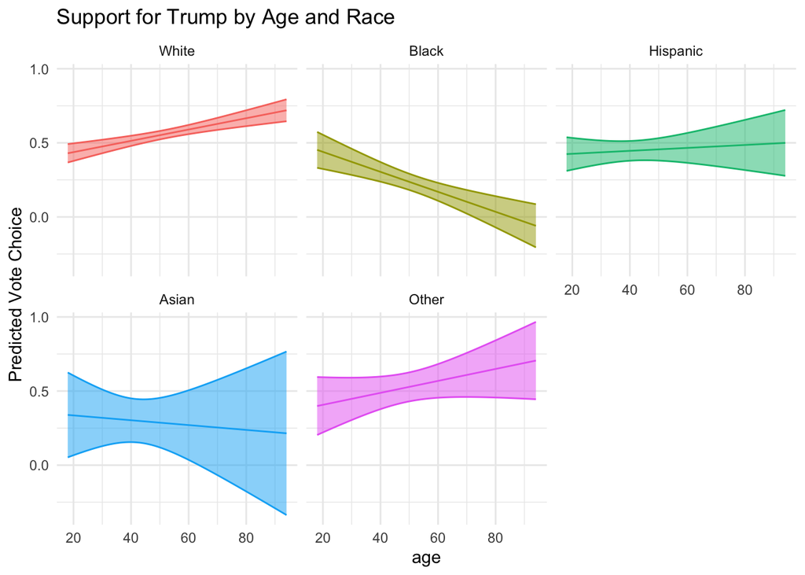

```r
# Predictors for m2
pred_dfm2 <- expand_grid(
  age = seq(min(df$age, na.rm =T), max(df$age, na.rm = T)),
  race_5cat = sort(unique(df$race_5cat))
)

# Predictions with confidence intervals
pred_dfm2 <- cbind(
  pred_dfm2,
  predict(m2, newdata = pred_dfm2, interval = "confidence")$fit
)

# Plot predictions from m2

fig_m2 <- pred_dfm2 %>%
  ggplot(aes(age, fit, col = race_5cat))+
  geom_ribbon(aes(ymin = lwr, ymax = upr,
    fill = race_5cat
    ),
    alpha = .5)+
  geom_line()+
  facet_wrap( ~ race_5cat)+
  theme_minimal()+
  guides(
    col = "none",
    fill = "none"
  )+
  labs(
    y = "Predicted Vote Choice",
    title = "Support for Trump by Age and Race"
  )

# Display figure
fig_m2
```

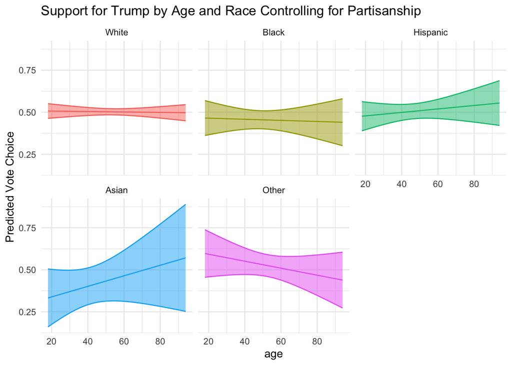

```r
# Predictors for m3
pred_dfm3 <- expand_grid(
  age = seq(min(df$age, na.rm =T), max(df$age, na.rm = T)),
  race_5cat = sort(unique(df$race_5cat)),
  partyid = mean(df$partyid, na.rm=T)
)

# Predictions with confidence intervals
pred_dfm3 <- cbind(
  pred_dfm3,
  predict(m3, newdata = pred_dfm3, interval = "confidence")$fit
)

# Plot predictions from m2

fig_m3 <- pred_dfm3 %>%
  ggplot(aes(age, fit, col = race_5cat))+
  geom_ribbon(aes(ymin = lwr, ymax = upr,
    fill = race_5cat
    ),
    alpha = .5)+
  geom_line()+
  facet_wrap( ~ race_5cat)+
  theme_minimal()+
  guides(
    col = "none",
    fill = "none"
  )+
  labs(
    y = "Predicted Vote Choice",
    title = "Support for Trump by Age and Race Controlling for Partisanship"
  )

fig_m3
```

## 6.3 Interperet results

Turning to the interaction model, we see that the magnitude of the coefficient on age (which corresponds to the marginal effect of age for white respondents) increases, while the coefficients on the interactions between age and racial indicators are generally negative, suggesting that the relationship between age and support for Trump is less strong for these racial and ethnic groups. Figure 1 helps clarify these marginal effects, as we see that slope for age is clearly positive for white respondents, clearly negative for Black respondents. The confidence intervals for the predicted values of the other racial and ethnic groups are generally wide, and consisent with positive, negative, or no relationship between age and vote choice.

Finally, looking at the model controlling for partisanship, we see that none of the relationships between age, race, and vote choice, remain statistically significant once we account for the relationships between partisanship and vote choice, and the relationships between partisanship and age and race. In sum, apparent demographic differences in support for Trump appear driven by the differences in partisan identification across racial groups and within age groups.

**YOU:**

# Take the Class Survey

## Footnotes

[^1]: Because `white` is first level the factor variable `race`